# Lab 2

2024-09-05

# 1. Creating an R project

1. Create folder for “Assignment1” in “FRE501” folder
2. Open Rstudio, create a new RProject (File>>New Project)
3. Select “Existing Directory”

[figure not shown]

4. Navigate to your Assignment1 folder using the “Browse” option

[figure not shown]

5. Click on “Create project”
6. Done!

# 2. Here() to locate your file

Check what your current working directory is. Type “here()” in your console. If it prints the path to your assignments folder, then path is correctly set!

Try

```
combined <- read_excel(here("data","assign1A_data.xlsx"),sheet="OI_combined")
```

If the path has been set to **some other directory**, follow these steps:

1. In the `Files` section (on your right), navigate to your “Assignment 1” folder and open that folder.

2. Click on the “gear” icon

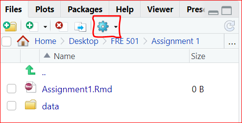

3. Click on “Set as working directory”
4. Now try to run the here() function as mentioned in the assignment

```
combined <- read_excel(here("data","assign1A_data.xlsx"),sheet="OI_combined")
```

```r
library(readxl)
library(here)
```

```r
wheat_2022 <- read_excel(here("data/wheat_excel.xlsx"), sheet = "2022")
head(wheat_2022)
```

```
## # A tibble: 6 × 9
##   Time        Open  High   Low  Last Change  `%Chg` Volume `Open Int`
##   <chr>      <dbl> <dbl> <dbl> <dbl>  <dbl>   <dbl>  <dbl>      <dbl>
## 1 10/31/2022  847.  847.  847.  847.  30.5   0.0373 190594     329100
## 2 10/28/2022  817.  817.  817.  817.  -5.25 -0.0064  62799     332745
## 3 10/27/2022  822   822   822   822   -1.25 -0.0015  71600     328840
## 4 10/26/2022  823.  823.  823.  823.   6.25  0.0076  69324     324517
## 5 10/25/2022  817   817   817   817   -1    -0.0012  80644     324137
## 6 10/24/2022  818   818   818   818   -9    -0.0109  63618     316858
```

If this **did not work** for you, got to Console and enter the following:

```
set_here("C:/Users/hp/Desktop/FRE 501/Assignments/Assignment1")
```

(you should enter the file path to your assignment folder)

Now, re-run your here() cell and it should work!

# 3. What is an RDS file?

1. RDS stands for R Data Serialization
2. It is a common format for saving R objects (dataframes) - preserves the state of R objects within sessions
3. Saving an object as an RDS file in R allows you to work on it later, unlike a file with a CSV extension.
4. RDS files are in a binary format, meaning it takes less time to import and export - use this for large dataframes

# 4. Package conflicts

## 4.1 What does dplyr::filter() mean?

This means that the package being used (filter()) is taken from the “dplyr” package. The reason this is mentioned explicitly is because filter() function exists in other libraries like the “stats” library, and they want you to make sure which filter() function you want. Both the filter() functions work differently.

The double colon (::) is to show relation of a package to a function.